# Close ended questions

Anna Quaglieri & Riccardo Amorati

11/04/2018

# 1 Read in data

```r
all <- read.csv("../02-descriptive_data/merged_filtered_imputedMedian_likertNumber.csv")
rownames(all) <- all$Resp.ID
```

# 2 Attrib

# 3 people that haven’t answered anything

# 4 External

```
|Context              |external           | Chosen|
|:--------------------|:------------------|------:|
|English in Germany   |duty5.external     |      0|
|English in Italy     |duty5.external     |      4|
|German in Australia  |duty5.external     |     13|
|Italian in Australia |duty5.external     |     19|
|English in Germany   |friends2.external  |     17|
|English in Italy     |friends2.external  |      3|
|German in Australia  |friends2.external  |     16|
|Italian in Australia |friends2.external  |     13|
|English in Germany   |noextern6.external |     38|
|English in Italy     |noextern6.external |     52|
|German in Australia  |noextern6.external |     39|
|Italian in Australia |noextern6.external |     19|
|English in Germany   |parents1.external  |     11|
|English in Italy     |parents1.external  |     12|
|German in Australia  |parents1.external  |     31|
|Italian in Australia |parents1.external  |     42|
|English in Germany   |press4.external    |      4|
|English in Italy     |press4.external    |     27|
|German in Australia  |press4.external    |     10|
|Italian in Australia |press4.external    |      0|
|English in Germany   |teachers3.external |     16|
|English in Italy     |teachers3.external |     13|
|German in Australia  |teachers3.external |     23|
|Italian in Australia |teachers3.external |     27|
```

```r
external <- c("other.external.richi")
external_data <- subset(all,select=c("Context",external))
table(external_data$other.external.richi)
```

[output not shown]

# 5 Influence

```
|Context              |influence                | Chosen|
|:--------------------|:------------------------|------:|
|English in Germany   |encouragement1.influence |     29|
|English in Italy     |encouragement1.influence |     34|
|German in Australia  |encouragement1.influence |     51|
|Italian in Australia |encouragement1.influence |     52|
|English in Germany   |insistence2.influence    |      0|
|English in Italy     |insistence2.influence    |      1|
|German in Australia  |insistence2.influence    |      4|
|Italian in Australia |insistence2.influence    |      7|
|English in Germany   |pressure3.influence      |      0|
|English in Italy     |pressure3.influence      |      5|
|German in Australia  |pressure3.influence      |      0|
|Italian in Australia |pressure3.influence      |      5|
```

# 6 Languages

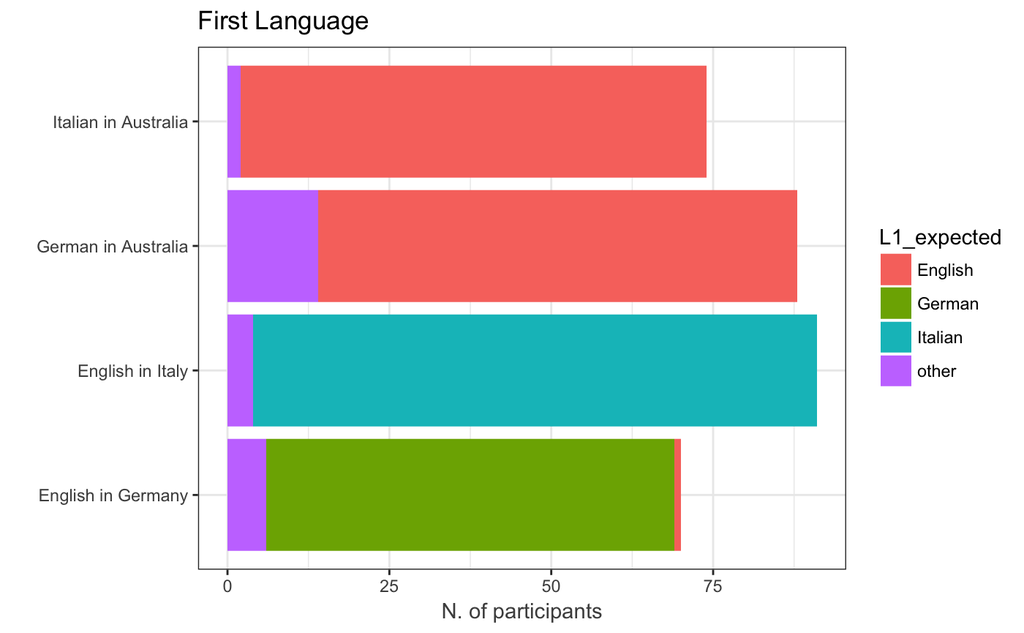

```
|Context              |L1_expected | Nspeaker|
|:--------------------|:-----------|--------:|
|English in Germany   |English     |        1|
|English in Germany   |German      |       63|
|English in Germany   |other       |        6|
|English in Italy     |Italian     |       87|
|English in Italy     |other       |        4|
|German in Australia  |English     |       74|
|German in Australia  |other       |       14|
|Italian in Australia |English     |       72|
|Italian in Australia |other       |        2|
```

# 7 L2 recoded

Richi recoded:

- year.studyL2, primary1.L2school, secondary2.L2sch (all the L2.school) and other.sector.richi

On the base of comments from participants.

```
[1] 0
```

# 8 Sector

```
                       Context transl1.sector research2.sector teaching3.sector business4.sector
5135909194    English in Italy              0                0                0                0
5184311630  English in Germany              0                0                0                0
5313843553 German in Australia              0                0                0                0
           tourism5.sector banking6.sector organisation7.sector communication8.sector intrelations9.sector
5135909194               0               0                    0                     0                    0
5184311630               0               0                    0                     0                    0
5313843553               0               0                    0                     0                    0
           Notsure10.sector other.sector.richi
5135909194                0                  0
5184311630                0                  0
5313843553                0                  0
```

# 9 L2school

```
[1] \character\
```

```
|Context              | CLS3.L2school| primary1.L2school| schooL2country5.L2school| secondary2.L2school| VSL4.L2school|
|:--------------------|-------------:|-----------------:|------------------------:|-------------------:|-------------:|
|German in Australia  |             6|                 9|                        9|                  53|             3|
|Italian in Australia |             9|                39|                        6|                  48|             3|
```

```
|                     | EXCHANGE| NA| SCHOOL.L2| NA|
|:--------------------|--------:|--:|---------:|--:|
|English in Germany   |        0|  0|         0|  0|
|English in Italy     |        0|  0|         0|  0|
|German in Australia  |        5| 82|         1|  0|
|Italian in Australia |        3| 71|         0|  0|
|NA                   |        0|  0|         0|  0|
```

# 10 L2.VCE

```
|                     | NA| No| Yes|
|:--------------------|--:|--:|---:|
|English in Germany   | 70|  0|   0|
|English in Italy     | 91|  0|   0|
|German in Australia  | 13| 27|  48|
|Italian in Australia | 12| 20|  42|
```

# 11 year.studyL2

# 12 private.lessons1.other.ways

```r
kable(table(all$private.lessons1.other.ways,all$Context,useNA = "always"))
```

[output not shown]

# 13 year.sem.abroad3.other.ways

```r
kable(table(all$year.sem.abroad3.other.ways,all$Context,useNA = "always"))
```

[output not shown]

# 14 study.holiday2.other.ways

```r
kable(table(all$study.holiday2.other.ways,all$Context,useNA = "always"))
```

[output not shown]

# 15 online.course4.other.ways

```r
kable(table(all$online.course4.other.ways,all$Context,useNA = "always"))
```

[output not shown]

# 16 other5.other.ways

```r
kable(table(all$other5.other.ways,all$Context,useNA = "always"))
```

[output not shown]

# 17 degree.role

```r
kable(table(all$degree.role,all$Context,useNA = "always"))
```

[output not shown]